# Bayesian Analysis of BioNTech/Pfizer SARS-COV-2 RNA Vaccine Efficacy Study Phase 2/3

Laksha Karthikeyan

2023-03-4

Consider the report: C4591001_Clinical_Protocol_Nov2020.pdf [A PHASE 1/2/3, PLACEBO-CONTROLLED, RANDOMIZED, OBSERVER-BLIND, DOSE-FINDING STUDY TO EVALUATE THE SAFETY, TOLERABILITY, IMMUNOGENICITY, AND EFFICACY OF SARS-COV-2 RNA VACCINE CANDIDATES AGAINST COVID-19 IN HEALTHY INDIVIDUALS (pages 99-101)]. Let $\theta$ be the probability that a subject who fell ill with Covid-19 is from the treatment group and $1-\theta$ the probability that the subject is from the control group. Assuming that 94 subjects fell ill to Covid-19 (with a sample efficacy above 90%) and at most 8 of those 94 subjects were vaccinated.

# Introduction

The purpose of this study is to examine the efficacy, safety, tolerability, and immunogencity of the prophylactic, SARS-COV-2 RNA vaccine candidates BNT162 against COVID-19. Phase 2/3 of the study particularly evaluates vaccine candidate BNT162b2 and vaccine efficacy (VE) based on posterior probability, considering VE>30% to be evidence of VE following the assumption of a true VE>60% after second-dose of BNT162b2. Posterior probability, in Bayesian statistics, is the updated probability of obtaining certain results given the data. The treatment group contains individuals who have become ill from COVID-19 who have been vaccinated prior to becoming infected, and the control group contains subjects who become ill with COVID-19 and have not been vaccinated. $\theta$ represents the probability that a subject becomes ill with COVID-19 and is from the treatment group while $1-\theta$ is the probability that this infected subject is from the control group. Thus, in this Bayesian analysis of the data, $\theta$ is utilized as the expected value in the Beta prior distribution of VE, likelihood function graph, and posterior distribution, which will ultimately show results relating to the efficacy of the vaccine candidate BNT162b2 at preventing infection of the COVID-19 virus. The assumption is used that of 94 subjects who fell ill to COVID-19, at most 8 of those 94 subjects were vaccinated.

# Methods

The Bayesian analysis in this study utilizes posterior probability to determine efficacy of the vaccine candidate BNT161b2 against COVID-19 through Beta prior distribution centered at $\theta$, as this accounts for uncertainty in the VE value in the prior distribution. The posterior distribution of $\theta$ displays the updated probabilities of a vaccinated indivudal falling ill with COVID-19 with the inclusion of the new observation, that of a sample of 94 subjects who fell ill to COVID-19, at most 8 were vaccinated. Furthermore, computing a 95% credible interval for $\theta$ by specifically using the 2.5% and 97.5% quantiles in the posterior distribution allows to find the high probability that a vaccinated subject who has fallen ill with COVID-19 is between a certain interval.

# Results

1. A Beta prior for $\theta$: $p(\theta)$=Beta$($a=0.5,b=0.5$)$, where $a$ and $b$ are the shape parameters of the Beta distribution. Plot the prior, likelihood and posterior as function of $\theta$.

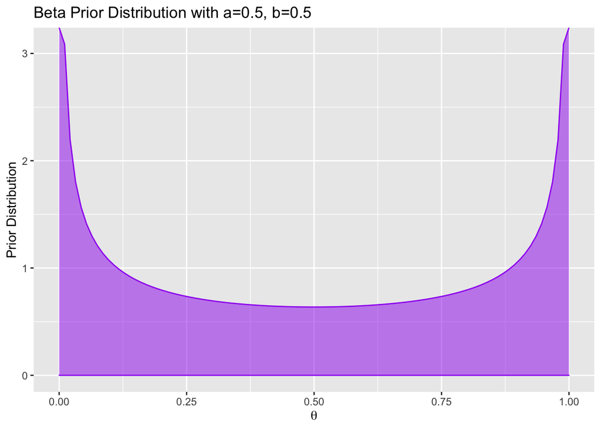

```r
# Beta Prior Distribution
library(ggplot2)
a.prior=0.5
b.prior=0.5

ggplot(data=data.frame(x=c(0,1)), aes(x)) + stat_function(geom="area",fun=dbeta, n=94, args=list(shape1=a.prior, shape2=b.prior), col="purple", fill="purple", alpha=0.5)+xlab(expression(theta))+ylab("Prior Distribution")+ggtitle("Beta Prior Distribution with a=0.5, b=0.5")
```

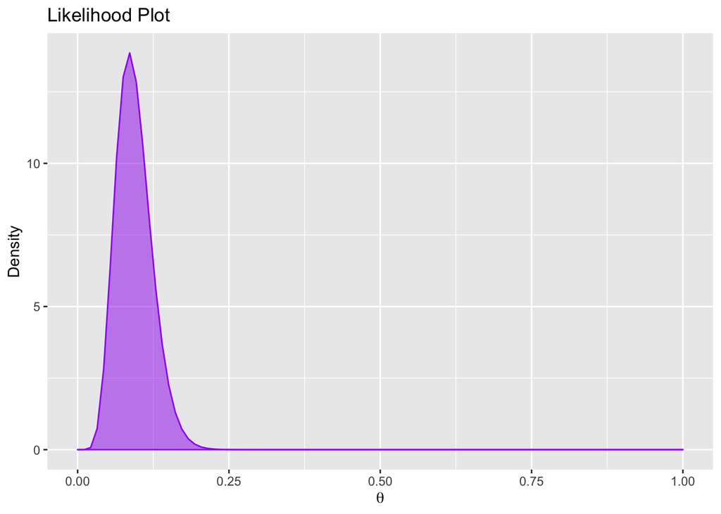

```r
# Likelihood Plot
theta = seq(0,1,94)
# 8 vaccinated subjects of sample size = 94 subjects who fell ill
y=8
num=94

ggplot(data=data.frame(theta=c(0,1)), aes(theta)) + stat_function(geom="area", fun=dbeta, n=94, args=list(y+1, num-y+1), col="purple", fill="purple", alpha=0.5)+xlab(expression(theta))+ylab("Density")+ggtitle("Likelihood Plot")
```

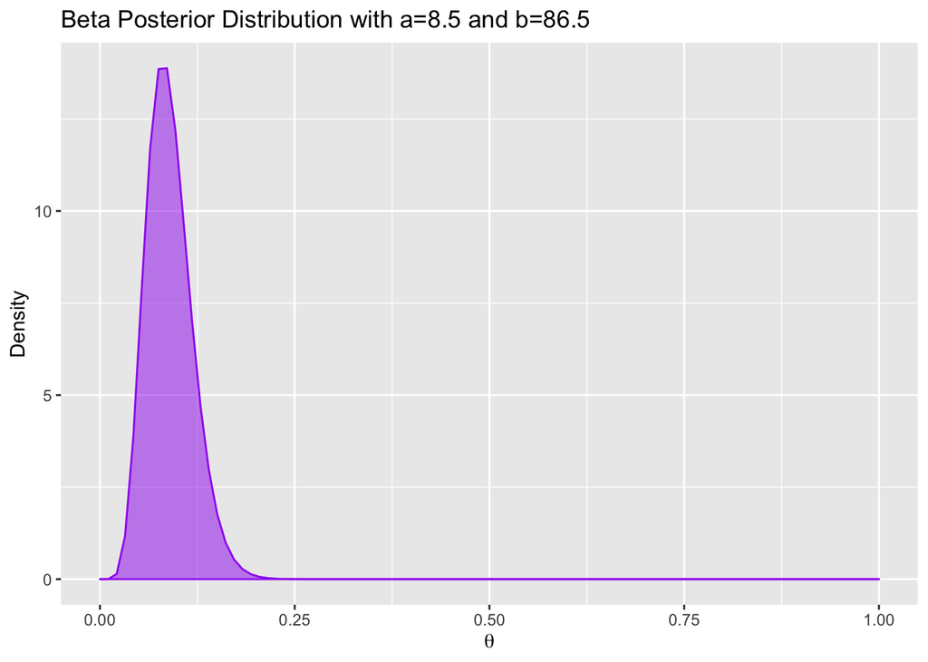

```r
# Posterior Distribution
theta=seq(0,1,94)
y=8
num=94
a.posterior = 0.5+y
b.posterior=0.5+num-y

ggplot(data=data.frame(theta=c(0,1)), aes(theta)) + stat_function(geom="area", fun=dbeta, n=94, args=list(shape1=a.posterior, shape2=b.posterior), col="purple", fill="purple", alpha=0.5)+xlab(expression(theta))+ylab("Density")+ggtitle("Beta Posterior Distribution with a=8.5 and b=86.5")
```

The posterior distribution of $\theta$ displays the updated probabilities of a vaccinated indivudal falling ill with COVID-19 with the inclusion of the new observation, that of a sample of 94 subjects who fell ill to COVID-19, 8 were vaccinated.

2. Compute the posterior probability of having a value of $\theta>0.4118$.

```r
post_prob <- 1-(pbeta(0.4118,a.posterior,b.posterior))
post_prob
```

```
## [1] 5.82645e-13
```

The posterior probability of having a value of $\theta>0.4118$ is 5.82645e-13.

```r
theta.cred.interval=qbeta(c(0.025, 0.975), a.posterior, b.posterior)
round(theta.cred.interval*100,1)
```

```
## [1]  4.1 15.4
```

```r
VE.cred.interval = rev((1-2*theta.cred.interval)/(1-theta.cred.interval))
round(VE.cred.interval*100,1)
```

```
## [1] 81.8 95.7
```

4. Plot the posterior empirical predictive density.

```r
library(LearnBayes)
library(extraDistr)
```

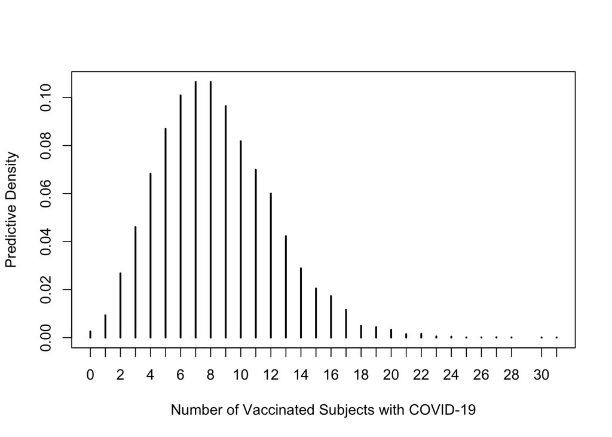

```r
n=94
y_n=rbbinom(10000, n, a.posterior, b.posterior)
plot(table(y_n)/10000, xlab="Number of Vaccinated Subjects with COVID-19", ylab="Predictive Density")
```

```r
e_value <- n*a.posterior/(a.posterior+b.posterior)
e_value
```

```
## [1] 8.410526
```

# Conclusions